# Deep Learning

## Assignment 5

The goal of this assignment is to train a Word2Vec skip-gram model over [Text8](http://mattmahoney.net/dc/textdata) data.

```python
# These are all the modules we'll be using later. Make sure you can import them
# before proceeding further.
%matplotlib inline
from __future__ import print_function
import collections
import math
import numpy as np
import os
import random
import tensorflow as tf
import zipfile
from matplotlib import pylab
from six.moves import range
from six.moves.urllib.request import urlretrieve
from sklearn.manifold import TSNE
```

Download the data from the source website if necessary.

```python
url = 'http://mattmahoney.net/dc/'

def maybe_download(filename, expected_bytes):
  """Download a file if not present, and make sure it's the right size."""
  if not os.path.exists(filename):
    filename, _ = urlretrieve(url + filename, filename)
  statinfo = os.stat(filename)
  if statinfo.st_size == expected_bytes:
    print('Found and verified %s' % filename)
  else:
    print(statinfo.st_size)
    raise Exception(
      'Failed to verify ' + filename + '. Can you get to it with a browser?')
  return filename

filename = maybe_download('text8.zip', 31344016)
```

```
Found and verified text8.zip
```

Read the data into a string.

```python
def read_data(filename):
  """Extract the first file enclosed in a zip file as a list of words"""
  with zipfile.ZipFile(filename) as f:
    data = tf.compat.as_str(f.read(f.namelist()[0])).split()
  return data

words = read_data(filename)
print('Data size %d' % len(words))
```

```
Data size 17005207
```

Build the dictionary and replace rare words with UNK token.

```python
vocabulary_size = 50000

def build_dataset(words):
  count = [['UNK', -1]]
  count.extend(collections.Counter(words).most_common(vocabulary_size - 1))
  dictionary = dict()
  for word, _ in count:
    dictionary[word] = len(dictionary)
  data = list()
  unk_count = 0
  for word in words:
    if word in dictionary:
      index = dictionary[word]
    else:
      index = 0  # dictionary['UNK']
      unk_count = unk_count + 1
    data.append(index)
  count[0][1] = unk_count
  reverse_dictionary = dict(zip(dictionary.values(), dictionary.keys()))
  return data, count, dictionary, reverse_dictionary

data, count, dictionary, reverse_dictionary = build_dataset(words)
print('Most common words (+UNK)', count[:5])
print('Sample data', data[:10])
del words  # Hint to reduce memory.
```

```
Most common words (+UNK) [['UNK', 418391], ('the', 1061396), ('of', 593677), ('and', 416629), ('one', 411764)]
Sample data [5239, 3084, 12, 6, 195, 2, 3137, 46, 59, 156]
```

Let's display the internal variables to better understand their structure:

```python
print(data[:10])
print(count[:10])
print(dictionary.items()[:10])
print(reverse_dictionary.items()[:10])
```

```
[5239, 3084, 12, 6, 195, 2, 3137, 46, 59, 156]
[['UNK', 418391], ('the', 1061396), ('of', 593677), ('and', 416629), ('one', 411764), ('in', 372201), ('a', 325873), ('to', 316376), ('zero', 264975), ('nine', 250430)]
[('fawn', 45848), ('homomorphism', 9648), ('nordisk', 39343), ('nunnery', 36075), ('chthonic', 33554), ('sowell', 40562), ('sonja', 38175), ('showa', 32906), ('woods', 6263), ('hsv', 44222)]
[(0, 'UNK'), (1, 'the'), (2, 'of'), (3, 'and'), (4, 'one'), (5, 'in'), (6, 'a'), (7, 'to'), (8, 'zero'), (9, 'nine')]
```

Function to generate a training batch for the skip-gram model.

```python
data_index = 0

def generate_batch(batch_size, num_skips, skip_window):
  global data_index
  assert batch_size % num_skips == 0
  assert num_skips <= 2 * skip_window
  batch = np.ndarray(shape=(batch_size), dtype=np.int32)
  labels = np.ndarray(shape=(batch_size, 1), dtype=np.int32)
  span = 2 * skip_window + 1 # [ skip_window target skip_window ]
  buffer = collections.deque(maxlen=span)
  for _ in range(span):
    buffer.append(data[data_index])
    data_index = (data_index + 1) % len(data)
  for i in range(batch_size // num_skips):
    target = skip_window  # target label at the center of the buffer
    targets_to_avoid = [ skip_window ]
    for j in range(num_skips):
      while target in targets_to_avoid:
        target = random.randint(0, span - 1)
      targets_to_avoid.append(target)
      batch[i * num_skips + j] = buffer[skip_window]
      labels[i * num_skips + j, 0] = buffer[target]
    buffer.append(data[data_index])
    data_index = (data_index + 1) % len(data)
  return batch, labels

print('data:', [reverse_dictionary[di] for di in data[:32]])

for num_skips, skip_window in [(2, 1), (4, 2)]:
    data_index = 0
    batch, labels = generate_batch(batch_size=16, num_skips=num_skips, skip_window=skip_window)
    print('\nwith num_skips = %d and skip_window = %d:' % (num_skips, skip_window))
    print('    batch:', [reverse_dictionary[bi] for bi in batch])
    print('    labels:', [reverse_dictionary[li] for li in labels.reshape(16)])

for num_skips, skip_window in [(2, 1), (4, 2)]:
    data_index = 1
    batch, labels = generate_batch(batch_size=16, num_skips=num_skips, skip_window=skip_window)
    print('\nwith num_skips = %d and skip_window = %d:' % (num_skips, skip_window))
    print('    batch:', [reverse_dictionary[bi] for bi in batch])
    print('    labels:', [reverse_dictionary[li] for li in labels.reshape(16)])
```

```
data: ['anarchism', 'originated', 'as', 'a', 'term', 'of', 'abuse', 'first', 'used', 'against', 'early', 'working', 'class', 'radicals', 'including', 'the', 'diggers', 'of', 'the', 'english', 'revolution', 'and', 'the', 'sans', 'UNK', 'of', 'the', 'french', 'revolution', 'whilst', 'the', 'term']

with num_skips = 2 and skip_window = 1:
    batch: ['originated', 'originated', 'as', 'as', 'a', 'a', 'term', 'term', 'of', 'of', 'abuse', 'abuse', 'first', 'first', 'used', 'used']
    labels: ['as', 'anarchism', 'a', 'originated', 'term', 'as', 'of', 'a', 'abuse', 'term', 'of', 'first', 'abuse', 'used', 'first', 'against']

with num_skips = 4 and skip_window = 2:
    batch: ['as', 'as', 'as', 'as', 'a', 'a', 'a', 'a', 'term', 'term', 'term', 'term', 'of', 'of', 'of', 'of']
    labels: ['a', 'term', 'anarchism', 'originated', 'as', 'of', 'originated', 'term', 'as', 'abuse', 'a', 'of', 'term', 'a', 'first', 'abuse']

with num_skips = 2 and skip_window = 1:
    batch: ['as', 'as', 'a', 'a', 'term', 'term', 'of', 'of', 'abuse', 'abuse', 'first', 'first', 'used', 'used', 'against', 'against']
    labels: ['originated', 'a', 'as', 'term', 'of', 'a', 'abuse', 'term', 'of', 'first', 'used', 'abuse', 'first', 'against', 'early', 'used']

with num_skips = 4 and skip_window = 2:
    batch: ['a', 'a', 'a', 'a', 'term', 'term', 'term', 'term', 'of', 'of', 'of', 'of', 'abuse', 'abuse', 'abuse', 'abuse']
    labels: ['of', 'originated', 'as', 'term', 'a', 'of', 'as', 'abuse', 'abuse', 'a', 'first', 'term', 'first', 'of', 'used', 'term']
```

Note: the labels is a sliding random value of the word surrounding the words of the batch.

It is not obvious with the output above, but all the data are based on index, and not the word directly.

```python
print(batch)
print(labels)
```

```
[   6    6    6    6  195  195  195  195    2    2    2    2 3137 3137 3137
 3137]
[[   2]
 [3084]
 [  12]
 [ 195]
 [   6]
 [   2]
 [  12]
 [3137]
 [3137]
 [   6]
 [  46]
 [ 195]
 [  46]
 [   2]
 [  59]
 [ 195]]
```

Train a skip-gram model.

```python
batch_size = 128
embedding_size = 128 # Dimension of the embedding vector.
skip_window = 1 # How many words to consider left and right.
num_skips = 2 # How many times to reuse an input to generate a label.
# We pick a random validation set to sample nearest neighbors. here we limit the
# validation samples to the words that have a low numeric ID, which by
# construction are also the most frequent.
valid_size = 16 # Random set of words to evaluate similarity on.
valid_window = 100 # Only pick dev samples in the head of the distribution.
valid_examples = np.array(random.sample(range(valid_window), valid_size))
num_sampled = 64 # Number of negative examples to sample.

graph = tf.Graph()

with graph.as_default(), tf.device('/cpu:0'):

  # Input data.
  train_dataset = tf.placeholder(tf.int32, shape=[batch_size])
  train_labels = tf.placeholder(tf.int32, shape=[batch_size, 1])
  valid_dataset = tf.constant(valid_examples, dtype=tf.int32)

  # Variables.
  embeddings = tf.Variable(
    tf.random_uniform([vocabulary_size, embedding_size], -1.0, 1.0))
  softmax_weights = tf.Variable(
    tf.truncated_normal([vocabulary_size, embedding_size],
                         stddev=1.0 / math.sqrt(embedding_size)))
  softmax_biases = tf.Variable(tf.zeros([vocabulary_size]))

  # Model.
  # Look up embeddings for inputs.
  embed = tf.nn.embedding_lookup(embeddings, train_dataset)
  # Compute the softmax loss, using a sample of the negative labels each time.
  loss = tf.reduce_mean(
    tf.nn.sampled_softmax_loss(softmax_weights, softmax_biases, embed,
                               train_labels, num_sampled, vocabulary_size))

  # Optimizer.
  optimizer = tf.train.AdagradOptimizer(1.0).minimize(loss)

  # Compute the similarity between minibatch examples and all embeddings.
  # We use the cosine distance:
  norm = tf.sqrt(tf.reduce_sum(tf.square(embeddings), 1, keep_dims=True))
  normalized_embeddings = embeddings / norm
  valid_embeddings = tf.nn.embedding_lookup(
    normalized_embeddings, valid_dataset)
  similarity = tf.matmul(valid_embeddings, tf.transpose(normalized_embeddings))
```

```python
num_steps = 100001

with tf.Session(graph=graph) as session:
  tf.initialize_all_variables().run()
  print('Initialized')
  average_loss = 0
  for step in range(num_steps):
    batch_data, batch_labels = generate_batch(
      batch_size, num_skips, skip_window)
    feed_dict = {train_dataset : batch_data, train_labels : batch_labels}
    _, l = session.run([optimizer, loss], feed_dict=feed_dict)
    average_loss += l
    if step % 2000 == 0:
      if step > 0:
        average_loss = average_loss / 2000
      # The average loss is an estimate of the loss over the last 2000 batches.
      print('Average loss at step %d: %f' % (step, average_loss))
      average_loss = 0
    # note that this is expensive (~20% slowdown if computed every 500 steps)
    if step % 10000 == 0:
      sim = similarity.eval()
      for i in range(valid_size):
        valid_word = reverse_dictionary[valid_examples[i]]
        top_k = 8 # number of nearest neighbors
        nearest = (-sim[i, :]).argsort()[1:top_k+1]
        log = 'Nearest to %s:' % valid_word
        for k in range(top_k):
          close_word = reverse_dictionary[nearest[k]]
          log = '%s %s,' % (log, close_word)
        print(log)
  final_embeddings = normalized_embeddings.eval()
```

```
Initialized
Average loss at step 0: 7.973985
Nearest to people: preserved, shear, cheats, refusing, elca, transcontinental, galician, ppg,
Nearest to called: suitability, extracellular, hangzhou, conducts, surrender, roadway, biographies, babylonians,
Nearest to there: clicks, pumps, hipc, depictions, streaming, overwritten, conifers, urartu,
Nearest to three: inadequately, idiopathic, ancona, epigram, northumbrian, rains, rquez, ldl,
Nearest to such: cylindrical, kanal, disposition, cao, denotation, spreads, engraver, outspoken,
Nearest to as: breakdancing, konqueror, sealing, eritreans, brubeck, olwen, denotation, marty,
Nearest to or: charlestown, gleaming, subsumed, proposal, anisotropic, goodfellas, auvergne, schloss,
Nearest to between: sufficed, privacy, amar, equates, peloponnesus, fuji, statuette, endowed,
Nearest to into: usr, glucagon, responds, rupture, caeiro, galvani, alexandra, pitfalls,
Nearest to an: copycat, darts, polytechnique, sartre, anglicanism, morrison, technologies, cortona,
Nearest to with: mansi, amortized, abendana, baal, ifrcs, unpaved, nokia, opposite,
Nearest to for: wadis, wide, optimal, accustomed, mezzo, davids, dns, retroviruses,
Nearest to i: lorica, conn, guadalajara, feat, krzy, randomization, yat, repression,
Nearest to in: transmigration, paralleled, uniquely, ouadda, coding, panama, worshipping, oems,
Nearest to the: reflex, marcellinus, anchovies, ecm, parlement, fitzroy, cavers, angels,
Nearest to years: eminem, fortunate, progression, signalled, elmore, disallowed, uvular, hotspot,
Average loss at step 2000: 4.363197
Average loss at step 4000: 3.864227
Average loss at step 6000: 3.793599
Average loss at step 8000: 3.684167
Average loss at step 10000: 3.617109
Nearest to people: preserved, transcontinental, mention, addressee, driver, myspace, flower, anarchists,
Nearest to called: conducts, shielded, eeg, chapels, extracellular, sisak, hangzhou, wandered,
Nearest to there: it, still, he, also, overwritten, not, they, pumps,
Nearest to three: five, four, six, eight, two, seven, nine, zero,
Nearest to such: kanal, known, processes, cylindrical, demo, dag, annoyed, disposition,
Nearest to as: login, sensation, keel, neighboring, capitalization, belong, by, denotation,
Nearest to or: and, characterizations, coerce, texans, s, organometallic, acct, subsidised,
Nearest to between: forsyth, laminar, moire, fuji, endowed, banana, in, equates,
Nearest to into: usr, caeiro, galvani, extradition, gerald, revealing, succeed, from,
Nearest to an: grimoires, unsettling, the, copycat, slings, terrible, anglicanism, ectopic,
Nearest to with: in, lilly, ohm, by, bayezid, mansi, ebrd, from,
Nearest to for: rothbard, towards, over, mamertines, of, cha, dubna, theodor,
Nearest to i: guadalajara, conn, juice, it, danner, malay, yetzirah, bra,
Nearest to in: of, on, during, at, by, subtype, panama, greatest,
Nearest to the: a, its, this, his, their, alamo, lavrenty, an,
Nearest to years: eminem, nzenberg, rescued, signalled, disallowed, center, sutras, cesium,
Average loss at step 12000: 3.604228
```

[output cut: 173 more lines]

```
Nearest to called: named, referred, overhaul, used, considered, www, misplaced, known,
Nearest to there: they, it, still, we, he, now, generally, often,
Nearest to three: four, two, five, seven, eight, six, zero, nine,
Nearest to such: known, well, regarded, these, spaceflights, follows, certain, many,
Nearest to as: sphinx, puritanism, notoc, varuna, equity, hotbed, segmented, gru,
Nearest to or: and, than, organometallic, coupe, houghton, adding, cafeteria, objecting,
Nearest to between: within, among, with, around, drilled, jun, goodall, rebelling,
Nearest to into: through, within, from, during, towards, off, across, attachments,
Nearest to an: grimoires, probus, unsettling, another, bleaching, copycat, roamed, xxxix,
Nearest to with: between, including, when, using, jets, embittered, in, to,
Nearest to for: without, when, hgp, while, after, during, if, dubna,
Nearest to i: you, we, ii, danner, v, t, they, g,
Nearest to in: during, throughout, within, until, on, among, of, from,
Nearest to the: a, their, your, lodge, his, its, this, our,
Nearest to years: days, hours, decades, centuries, months, times, year, minutes,
```

This is what an embedding looks like:

```python
print(final_embeddings[0])
```

```
[-0.02051404 -0.01841166 -0.1244709   0.05074964 -0.06100134 -0.00200008
  0.11170887 -0.08766419  0.02409515  0.1101989   0.16667137 -0.00165691
 -0.14681569 -0.11056326 -0.03933677 -0.02154945 -0.10062175 -0.05628699
  0.01922635  0.1639808   0.01684226 -0.0540074  -0.03108865  0.01777779
  0.04706197 -0.01260165 -0.29304644 -0.0302702  -0.10937209  0.03770837
  0.15830405  0.06936062  0.16194052 -0.03061437  0.04542041 -0.07499804
 -0.00841922  0.01684443  0.07148984 -0.06406043  0.09492613 -0.09933698
 -0.00687152 -0.08409496  0.01544465 -0.11804878  0.14000055 -0.09653874
  0.02137009  0.01145039 -0.06205352  0.02977284 -0.01883831 -0.11986119
  0.05494772  0.05486212 -0.00120243 -0.02710927 -0.0569164  -0.11858083
 -0.01223189  0.09930295  0.09467366 -0.02073516 -0.12372935  0.00244062
  0.05924704  0.14948699 -0.1119219  -0.07551062  0.00928106 -0.01831606
 -0.05067647 -0.10931925  0.0324928   0.00191521 -0.01634123  0.08661727
  0.12392872 -0.01820764 -0.16330577 -0.24632891  0.02271111  0.00542232
  0.00801045 -0.00690781  0.16911526  0.01407609  0.02365589 -0.07911306
  0.07899767  0.16927634  0.07133543  0.05735794  0.08887751  0.19834489
  0.17564225 -0.08074389  0.17213371  0.04207939  0.02885242  0.02857619
 -0.05606408 -0.12006876 -0.07494419 -0.10423107 -0.05341928 -0.09745979
 -0.13150343  0.05612956 -0.08829316  0.12047683  0.00201026 -0.09098013
  0.00637597  0.08963603 -0.02186407  0.01224304 -0.02592809  0.05893643
 -0.0640655   0.00615067 -0.07741468  0.10470562  0.01330675  0.08730693
 -0.0361954  -0.05102392]
```

All the values are abstract, there is practical meaning of the them. Moreover, the final embeddings are normalized as you can see here:

```python
print(np.sum(np.square(final_embeddings[0])))
```

```
1.0
```

```python
num_points = 400

tsne = TSNE(perplexity=30, n_components=2, init='pca', n_iter=5000)
two_d_embeddings = tsne.fit_transform(final_embeddings[1:num_points+1, :])
```

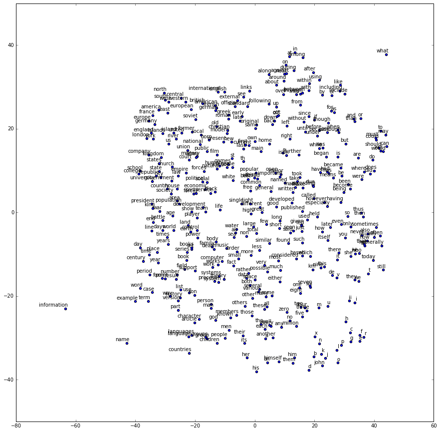

```python
def plot(embeddings, labels):
  assert embeddings.shape[0] >= len(labels), 'More labels than embeddings'
  pylab.figure(figsize=(15,15))  # in inches
  for i, label in enumerate(labels):
    x, y = embeddings[i,:]
    pylab.scatter(x, y)
    pylab.annotate(label, xy=(x, y), xytext=(5, 2), textcoords='offset points',
                   ha='right', va='bottom')
  pylab.show()

words = [reverse_dictionary[i] for i in range(1, num_points+1)]
plot(two_d_embeddings, words)
```

## Problem

An alternative to skip-gram is another Word2Vec model called [CBOW](http://arxiv.org/abs/1301.3781) (Continuous Bag of Words). In the CBOW model, instead of predicting a context word from a word vector, you predict a word from the sum of all the word vectors in its context. Implement and evaluate a CBOW model trained on the text8 dataset.

For the continuous bag of words, the train inputs are slightly different from the skip-gram:

```python
data_index = 0

def generate_batch(batch_size, bag_window):
  global data_index
  span = 2 * bag_window + 1 # [ bag_window target bag_window ]
  batch = np.ndarray(shape=(batch_size, span - 1), dtype=np.int32)
  labels = np.ndarray(shape=(batch_size, 1), dtype=np.int32)
  buffer = collections.deque(maxlen=span)
  for _ in range(span):
    buffer.append(data[data_index])
    data_index = (data_index + 1) % len(data)
  for i in range(batch_size):
    # just for testing
    buffer_list = list(buffer)
    labels[i, 0] = buffer_list.pop(bag_window)
    batch[i] = buffer_list
    # iterate to the next buffer
    buffer.append(data[data_index])
    data_index = (data_index + 1) % len(data)
  return batch, labels

print('data:', [reverse_dictionary[di] for di in data[:16]])

for bag_window in [1, 2]:
  data_index = 0
  batch, labels = generate_batch(batch_size=4, bag_window=bag_window)
  print('\nwith bag_window = %d:' % (bag_window))
  print('    batch:', [[reverse_dictionary[w] for w in bi] for bi in batch])
  print('    labels:', [reverse_dictionary[li] for li in labels.reshape(4)])
```

```
data: ['anarchism', 'originated', 'as', 'a', 'term', 'of', 'abuse', 'first', 'used', 'against', 'early', 'working', 'class', 'radicals', 'including', 'the']

with bag_window = 1:
    batch: [['anarchism', 'as'], ['originated', 'a'], ['as', 'term'], ['a', 'of']]
    labels: ['originated', 'as', 'a', 'term']

with bag_window = 2:
    batch: [['anarchism', 'originated', 'a', 'term'], ['originated', 'as', 'term', 'of'], ['as', 'a', 'of', 'abuse'], ['a', 'term', 'abuse', 'first']]
    labels: ['as', 'a', 'term', 'of']
```

Note the instruction change on the loss function, with `reduce_sum` to sum the word vectors in the context:

```python
batch_size = 128
embedding_size = 128 # Dimension of the embedding vector.
###skip_window = 1 # How many words to consider left and right.
###num_skips = 2 # How many times to reuse an input to generate a label.
bag_window = 2 # How many words to consider left and right.
# We pick a random validation set to sample nearest neighbors. here we limit the
# validation samples to the words that have a low numeric ID, which by
# construction are also the most frequent.
valid_size = 16 # Random set of words to evaluate similarity on.
valid_window = 100 # Only pick dev samples in the head of the distribution.
valid_examples = np.array(random.sample(range(valid_window), valid_size))
num_sampled = 64 # Number of negative examples to sample.

graph = tf.Graph()

with graph.as_default(), tf.device('/cpu:0'):

  # Input data.
  train_dataset = tf.placeholder(tf.int32, shape=[batch_size, bag_window * 2])
  train_labels = tf.placeholder(tf.int32, shape=[batch_size, 1])
  valid_dataset = tf.constant(valid_examples, dtype=tf.int32)

  # Variables.
  embeddings = tf.Variable(
    tf.random_uniform([vocabulary_size, embedding_size], -1.0, 1.0))
  softmax_weights = tf.Variable(
    tf.truncated_normal([vocabulary_size, embedding_size],
                         stddev=1.0 / math.sqrt(embedding_size)))
  softmax_biases = tf.Variable(tf.zeros([vocabulary_size]))

  # Model.
  # Look up embeddings for inputs.
  embeds = tf.nn.embedding_lookup(embeddings, train_dataset)
  # Compute the softmax loss, using a sample of the negative labels each time.
  loss = tf.reduce_mean(
    tf.nn.sampled_softmax_loss(softmax_weights, softmax_biases, tf.reduce_sum(embeds, 1),
                               train_labels, num_sampled, vocabulary_size))

  # Optimizer.
  optimizer = tf.train.AdagradOptimizer(1.0).minimize(loss)

  # Compute the similarity between minibatch examples and all embeddings.
  # We use the cosine distance:
  norm = tf.sqrt(tf.reduce_sum(tf.square(embeddings), 1, keep_dims=True))
  normalized_embeddings = embeddings / norm
  valid_embeddings = tf.nn.embedding_lookup(
    normalized_embeddings, valid_dataset)
  similarity = tf.matmul(valid_embeddings, tf.transpose(normalized_embeddings))
```

```python
num_steps = 100001

with tf.Session(graph=graph) as session:
  tf.initialize_all_variables().run()
  print('Initialized')
  average_loss = 0
  for step in range(num_steps):
    batch_data, batch_labels = generate_batch(
      batch_size, bag_window)
    feed_dict = {train_dataset : batch_data, train_labels : batch_labels}
    _, l = session.run([optimizer, loss], feed_dict=feed_dict)
    average_loss += l
    if step % 2000 == 0:
      if step > 0:
        average_loss = average_loss / 2000
      # The average loss is an estimate of the loss over the last 2000 batches.
      print('Average loss at step %d: %f' % (step, average_loss))
      average_loss = 0
    # note that this is expensive (~20% slowdown if computed every 500 steps)
    if step % 10000 == 0:
      sim = similarity.eval()
      for i in range(valid_size):
        valid_word = reverse_dictionary[valid_examples[i]]
        top_k = 8 # number of nearest neighbors
        nearest = (-sim[i, :]).argsort()[1:top_k+1]
        log = 'Nearest to %s:' % valid_word
        for k in range(top_k):
          close_word = reverse_dictionary[nearest[k]]
          log = '%s %s,' % (log, close_word)
        print(log)
  final_embeddings = normalized_embeddings.eval()
```

```
Initialized
Average loss at step 0: 7.983871
Nearest to an: ambiguously, tennessee, cats, regents, numerals, inpatient, madre, krak,
Nearest to d: woolly, atypical, climatic, textual, caapi, sungorus, collusion, disarmament,
Nearest to one: modi, optimizations, williams, overtake, finned, glissando, inciting, gasoline,
Nearest to may: fogo, kwanzaa, rivaled, doi, cavour, cante, tansley, incorruptible,
Nearest to has: pollock, literatures, existential, evelyn, inspector, ventricle, sweeps, tending,
Nearest to while: embouchure, analogue, petomane, etymology, etienne, referencing, starvation, hinds,
Nearest to will: waived, introduced, lithography, purge, nss, fabian, torquato, helicopters,
Nearest to nine: dore, promise, ailments, forty, boast, tarleton, courtney, apo,
Nearest to but: fucked, catalyzed, uart, commemorating, minicomputers, theatrically, sombart, meshech,
Nearest to are: bosch, handedly, dummies, bearings, repulsive, allegedly, eph, nk,
Nearest to this: shore, smog, dwell, injuries, poet, engraver, wafers, leviathan,
Nearest to when: derives, postfix, shimei, warlords, gorbachev, obtain, whale, prophesies,
Nearest to see: symbolized, algebra, fanpage, undesirable, jena, exerting, sierpinski, albans,
Nearest to up: cumming, thresholds, organic, ullman, manoeuvre, cnt, maguey, philanthropic,
Nearest to time: connie, amnesia, photoelectric, archdiocese, tennant, auburn, turbofan, rubicon,
Nearest to is: silicon, organisms, honesty, ghola, duckworth, glaze, wealthier, sheldon,
Average loss at step 2000: 7.571952
Average loss at step 4000: 4.962989
Average loss at step 6000: 5.264466
Average loss at step 8000: 4.020034
Average loss at step 10000: 3.823763
Nearest to an: the, a, expense, contends, thumb, stroke, bad, ontario,
Nearest to d: b, chicxulub, qf, kotzebue, balls, berenguer, apo, mustelids,
Nearest to one: crannog, fmln, accented, vivian, adl, baths, nesting, amedeo,
Nearest to may: can, should, could, would, might, must, will, cannot,
Nearest to has: had, have, was, is, agilent, finegold, lockyer, schottky,
Nearest to while: and, of, creed, than, thus, secundus, width, athanasian,
Nearest to will: would, must, creed, fish, at, oneself, thus, to,
Nearest to nine: eight, seven, five, six, zero, iga, three, apollo,
Nearest to but: however, meso, yamaha, korean, encounter, which, does, injustice,
Nearest to are: is, include, fish, creed, of, were, possibly, at,
Nearest to this: what, nigeria, stings, physiol, chili, dalek, danielle, husayn,
Nearest to when: where, fertilize, relative, sovereignty, because, oxidise, by, awake,
Nearest to see: utica, metonic, rimfire, subgroups, declarative, ratsiraka, commoner, bani,
Nearest to up: ranges, azores, thresholds, mano, imax, application, down, migrated,
Nearest to time: least, prosciutto, oxidant, hellish, place, end, kennel, year,
Nearest to is: are, was, of, holds, include, will, at, a,
Average loss at step 12000: 3.904979
```

[output cut: 173 more lines]

```
Nearest to d: b, pricing, kocher, wheat, deansgate, tightening, berenguer, wiesbaden,
Nearest to one: implicated, allein, crannog, excerpted, hoop, heraclius, cocos, irreconcilable,
Nearest to may: might, should, can, could, would, will, must, cannot,
Nearest to has: had, have, having, contains, includes, is, holds, takes,
Nearest to while: although, where, however, but, savory, though, until, when,
Nearest to will: would, should, could, might, can, may, cannot, must,
Nearest to nine: eight, seven, five, six, zero, july, four, june,
Nearest to but: however, although, and, though, than, while, or, nor,
Nearest to are: were, is, was, include, exist, contain, semmelweis, have,
Nearest to this: which, some, another, every, piecewise, fateful, any, that,
Nearest to when: if, where, because, although, though, before, that, while,
Nearest to see: include, allow, references, known, allows, say, but, schechter,
Nearest to up: off, down, together, out, back, forward, forth, sends,
Nearest to time: moment, stage, period, least, start, night, distances, subpixels,
Nearest to is: was, are, makes, exists, includes, remains, contains, provides,
```

```python
num_points = 400

tsne = TSNE(perplexity=30, n_components=2, init='pca', n_iter=5000)
two_d_embeddings = tsne.fit_transform(final_embeddings[1:num_points+1, :])
```

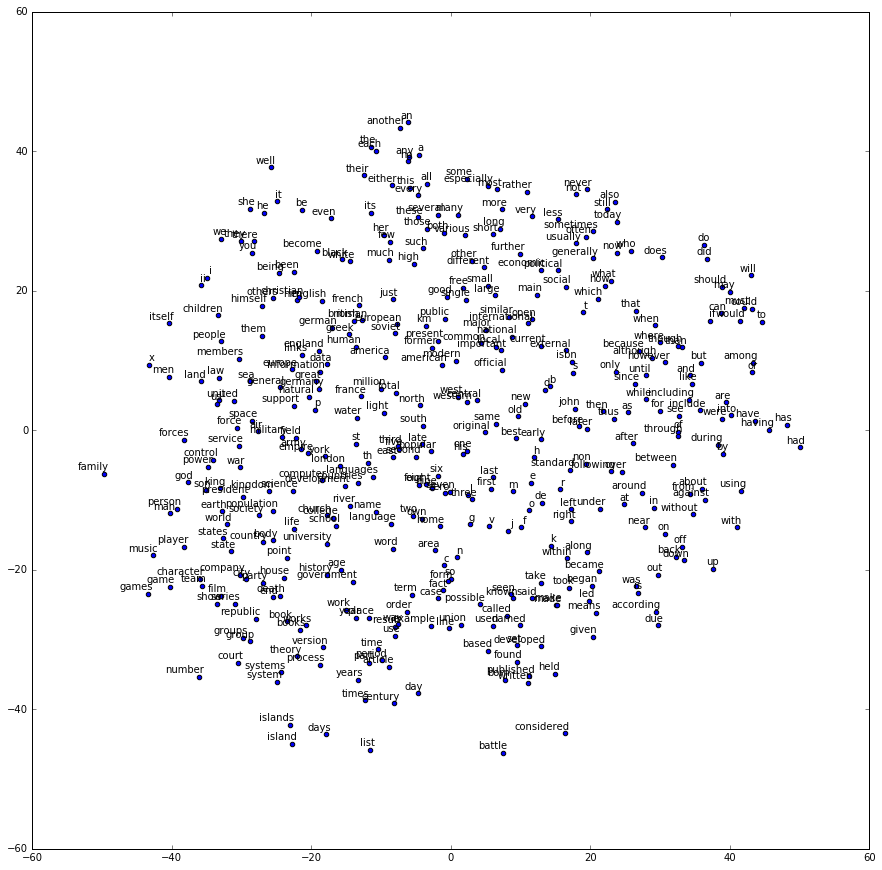

```python
def plot(embeddings, labels):
  assert embeddings.shape[0] >= len(labels), 'More labels than embeddings'
  pylab.figure(figsize=(15,15))  # in inches
  for i, label in enumerate(labels):
    x, y = embeddings[i,:]
    pylab.scatter(x, y)
    pylab.annotate(label, xy=(x, y), xytext=(5, 2), textcoords='offset points',
                   ha='right', va='bottom')
  pylab.show()

words = [reverse_dictionary[i] for i in range(1, num_points+1)]
plot(two_d_embeddings, words)
```

Some clusters are less obvious (like the standalone characters), but it clearly totaly works!

How does your CBOW model perform compared to the given Word2Vec model? (to be answered)

At the first sight, they look similar. The CBOW is a more compact.